# Notebook

## KNN Classifier : K-nearest-neighbors

C'est l'un des algorithmes les plus simples pour commencer. Le classificateur recherche les K points les plus proches. K définit le nombre de points voisins utilisés pour prendre une décision. Par défaut, il utilise 5 K points pour prendre une décision.

Cet algorithme est simple, mais il ne fonctionne pas très bien avec des ensembles de données comportant des centaines de features, car il devient très lent.

https://scikit-learn.org/stable/modules/generated/sklearn.neighbors.KNeighborsClassifier.html

### Installer le module scikit learn

```
sudo pip3 install -U scikit-learn
```

### Installer le module matplotlib

```
sudo pip3 install -U matplotlib
```

```python
from sklearn.datasets import load_breast_cancer
from sklearn.neighbors import KNeighborsClassifier
from sklearn.model_selection import train_test_split

import matplotlib.pyplot as plt
%matplotlib inline
```

```python
cancer = load_breast_cancer()
```

### Installer le module mg-learn

```
sudo pip3 install mglearn
```

```python
import sys
print(sys.executable)
```

```
/usr/bin/python3
```

#### Install a pip package in the current Jupyter kernel

```python
import sys
!{sys.executable} -m pip install mglearn
```

```
     ━━━━━━━━━━━━━━━━━━━━━━━━━━━━━━━━━━━━━━ 581.4/581.4 kB 21.2 MB/s eta 0:00:00
```

#### Illustration du classificateur KNN avec le module mg-learn :

Nous utilisons 3 voisins pour l'illustration.

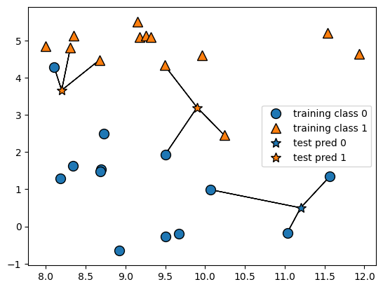

```python
import warnings
warnings.filterwarnings('ignore')

import mglearn
from sklearn.datasets import make_blobs

mglearn.plots.plot_knn_classification(n_neighbors=3)
```

Supposons que :

- Les cercles bleus représentent les tumeurs malignes
- Les triangles orange les tumeurs bénignes

(comme appris par notre classificateur KNN).

- Les étoiles représentent un nouvel échantillon.

```python
print(cancer.target)
```

```
[0 0 0 0 0 0 0 0 0 0 0 0 0 0 0 0 0 0 0 1 1 1 0 0 0 0 0 0 0 0 0 0 0 0 0 0 0
 1 0 0 0 0 0 0 0 0 1 0 1 1 1 1 1 0 0 1 0 0 1 1 1 1 0 1 0 0 1 1 1 1 0 1 0 0
 1 0 1 0 0 1 1 1 0 0 1 0 0 0 1 1 1 0 1 1 0 0 1 1 1 0 0 1 1 1 1 0 1 1 0 1 1
 1 1 1 1 1 1 0 0 0 1 0 0 1 1 1 0 0 1 0 1 0 0 1 0 0 1 1 0 1 1 0 1 1 1 1 0 1
 1 1 1 1 1 1 1 1 0 1 1 1 1 0 0 1 0 1 1 0 0 1 1 0 0 1 1 1 1 0 1 1 0 0 0 1 0
 1 0 1 1 1 0 1 1 0 0 1 0 0 0 0 1 0 0 0 1 0 1 0 1 1 0 1 0 0 0 0 1 1 0 0 1 1
 1 0 1 1 1 1 1 0 0 1 1 0 1 1 0 0 1 0 1 1 1 1 0 1 1 1 1 1 0 1 0 0 0 0 0 0 0
 0 0 0 0 0 0 0 1 1 1 1 1 1 0 1 0 1 1 0 1 1 0 1 0 0 1 1 1 1 1 1 1 1 1 1 1 1
 1 0 1 1 0 1 0 1 1 1 1 1 1 1 1 1 1 1 1 1 1 0 1 1 1 0 1 0 1 1 1 1 0 0 0 1 1
 1 1 0 1 0 1 0 1 1 1 0 1 1 1 1 1 1 1 0 0 0 1 1 1 1 1 1 1 1 1 1 1 0 0 1 0 0
 0 1 0 0 1 1 1 1 1 0 1 1 1 1 1 0 1 1 1 0 1 1 0 0 1 1 1 1 1 1 0 1 1 1 1 1 1
 1 0 1 1 1 1 1 0 1 1 0 1 1 1 1 1 1 1 1 1 1 1 1 0 1 0 0 1 0 1 1 1 1 1 0 1 1
 0 1 0 1 1 0 1 0 1 1 1 1 1 1 1 1 0 0 1 1 1 1 1 1 0 1 1 1 1 1 1 1 1 1 1 0 1
 1 1 1 1 1 1 0 1 0 1 1 0 1 1 1 1 1 0 0 1 0 1 0 1 1 1 1 1 0 1 1 0 1 0 1 0 0
 1 1 1 0 1 1 1 1 1 1 1 1 1 1 1 0 1 0 0 1 1 1 1 1 1 1 1 1 1 1 1 1 1 1 1 1 1
 1 1 1 1 1 1 1 0 0 0 0 0 0 1]
```

#### Construct and train the KNN model :

```python
from sklearn.datasets import load_breast_cancer
from sklearn.neighbors import KNeighborsClassifier
from sklearn.model_selection import train_test_split

import matplotlib.pyplot as plt
%matplotlib inline

cancer = load_breast_cancer()
```

### Diviser l'ensemble de données

1. stratify :

les données sont divisées de manière stratifiée, en utilisant cancer.target comme étiquettes de classe.  
Par exemple, s'il s'agit d'une variable catégorielle binaire avec des valeurs 0 et 1 et qu'il y a 25 % de zéros et 75 % de uns,  
stratify=target s'assurera que votre répartition aléatoire comporte 25 % de 0 et 75 % de 1.

2. random_state :

contrôle le mélange appliqué aux données avant l'application de la division.

weights{‘uniform’, ‘distance’, ‘callable’}, default=’uniform’

```python
X_train, X_test, y_train, y_test = train_test_split(cancer.data, cancer.target, stratify=cancer.target, random_state=42)

knn = KNeighborsClassifier()
knn.fit(X_train, y_train)
```

```
KNeighborsClassifier()
```

knn.score :  
Mean accuracy of self.predict(X) /wrt y.

```python
# Let's evaluate the algorithm
print('Accuracy of KNN n-5, on the training set: {:.3f}'.format(knn.score(X_train, y_train)))
print('Accuracy of KNN n-5, on the test set: {:.3f}'.format(knn.score(X_test, y_test)))
```

```
Accuracy of KNN n-5, on the training set: 0.946
Accuracy of KNN n-5, on the test set: 0.930
```

Précision de KNN n-5, sur l'ensemble de test : 0.930  
Cela signifie que l'algorithme KNN est capable de classer correctement 93% des données testées.  
C'est un bon score, mais pouvons-nous travailler sur les paramètres pour l'améliorer encore ?

Concentrons-nous sur le nombre de voisins.

Rediviser l'ensemble de données :

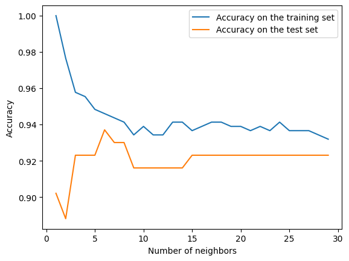

```python
X_train, X_test, y_train, y_test = train_test_split(cancer.data, cancer.target, stratify=cancer.target, random_state=66)

training_accuracy = []
test_accuracy = []

neighbors_settings = range(1, 30)

for n_neighbors in neighbors_settings:
    clf = KNeighborsClassifier(n_neighbors=n_neighbors)
    clf.fit(X_train, y_train)
    training_accuracy.append(clf.score(X_train, y_train))
    test_accuracy.append(clf.score(X_test, y_test))

# Display the results
plt.plot(neighbors_settings, training_accuracy, label='Accuracy on the training set')
plt.plot(neighbors_settings, test_accuracy, label='Accuracy on the test set')
plt.ylabel('Accuracy')
plt.xlabel('Number of neighbors')
plt.legend()
```

### L'algorithme semble mieux fonctionner avec 6 voisins

- Par défaut, nous avons pris toutes les caractéristiques de l'ensemble de données.
- Quelles sont les caractéristiques les plus significatives ?

```python
import numpy as np
import pandas as pd

from sklearn.model_selection import cross_val_score

clf = KNeighborsClassifier()
n_feats = cancer.data.shape[1]
y =  cancer.target

sign_dict = {}

for i in range(n_feats):
    X = cancer.data[:, i].reshape(-1, 1)
    scores = cross_val_score(clf, X, y, cv=3)
    sign_dict[i]=scores.mean()
    sign_dict = {k: v for k, v in sorted(sign_dict.items(), key=lambda item: item[1],reverse=True)}
    #print(f'{i}        {:g}')
    #print(type(scores.mean()))

nd = []

for v in sign_dict:
    nd.append ([cancer.feature_names[v], sign_dict[v]])

pdf = pd.DataFrame(data=nd, columns=['Feature','Accuracy'])
pdf
```

|  | Feature | Accuracy |
| --- | --- | --- |
| 0 | mean concave points | 0.913905 |
| 1 | worst concave points | 0.894551 |
| 2 | worst perimeter | 0.891033 |
| 3 | worst area | 0.889297 |
| 4 | worst radius | 0.889279 |
| 5 | mean perimeter | 0.873480 |
| 6 | mean radius | 0.869981 |
| 7 | mean concavity | 0.868208 |
| 8 | mean area | 0.866453 |
| 9 | area error | 0.855918 |
| 10 | worst concavity | 0.833046 |
| 11 | perimeter error | 0.790968 |
| 12 | radius error | 0.776831 |
| 13 | mean compactness | 0.768050 |
| 14 | worst compactness | 0.753913 |
| 15 | worst texture | 0.692342 |
| 16 | concave points error | 0.680089 |
| 17 | concavity error | 0.674863 |
| 18 | worst symmetry | 0.664327 |
| 19 | worst smoothness | 0.659055 |
| 20 | compactness error | 0.652047 |
| 21 | worst fractal dimension | 0.644946 |
| 22 | mean texture | 0.644853 |
| 23 | mean smoothness | 0.622092 |
| 24 | mean symmetry | 0.620282 |
| 25 | mean fractal dimension | 0.615140 |
| 26 | smoothness error | 0.587070 |
| 27 | fractal dimension error | 0.569489 |
| 28 | texture error | 0.555370 |
| 29 | symmetry error | 0.550070 |

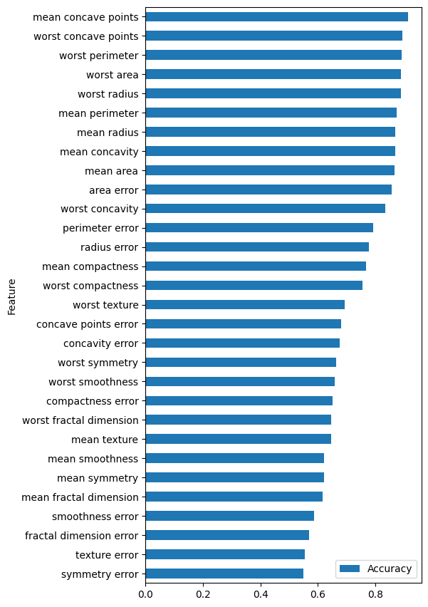

```python
import matplotlib.pyplot as plt
import matplotlib as matplotlib
from matplotlib.pyplot import figure

pdf = pdf.sort_values(by=['Accuracy'])

pdf.plot(kind='barh',x='Feature',y='Accuracy',orientation='horizontal')
fig = matplotlib.pyplot.gcf()
fig.set_size_inches(5, 10.5)
plt.show()
```

#### Une façon d'améliorer la précision du modèle :

Nous pouvons améliorer le modèle en sélectionnant les caractéristiques les plus pertinentes et en éliminant celles qui sont moins importantes. Pour chaque modification de la liste des caractéristiques, on entraîne le modèle et on observe l'évolution du score.